# Introducción

Autor/a

Aníbal Olivera

Fecha de publicación

8 de enero de 2025

## Revisitando las Ego-redes

Tradicionalmente, las encuestas se analizan asumiendo independencia entre observaciones (encuestados). Sin embargo, el supuesto **i.i.d.** (independientes e idénticamente distribuidas) se viola cuando las encuestas contienen items de “generación de nombres”.

Si representas tu dataset a nivel de díadas (ego–alter), el mismo ego $i$ aparece en varias filas: $(i, j_1), (i, j_2), \dots, (i, j_{k_i})$.

¿Entonces “todas” las encuestas ego violan i.i.d.?

Depende de la unidad de análisis:

- Si se analiza a nivel díada (**ego–alter**): en general **no** se puede asumir independencia entre filas, por lo anterior.
- Si se analiza a nivel **ego** (una fila por encuestado): es mucho más razonable tratar a los egos como i.i.d. entre sí (sujeto a diseño muestral/pesos), porque cada ego es una unidad muestral primaria.

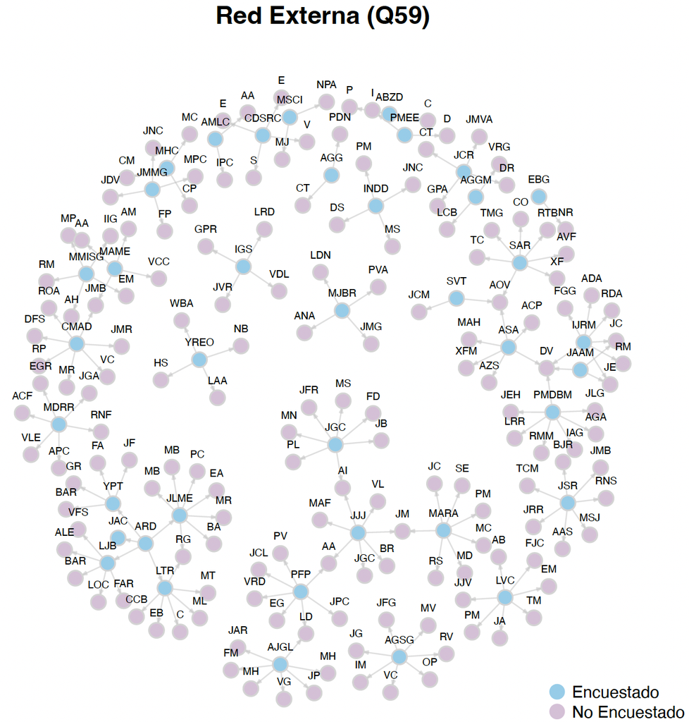

Example of real ego-networks.

Eso induce correlación entre observaciones porque esas filas comparten características no observadas del ego (p. ej., sociabilidad, propensión a nominar, sesgo de reporte, “grado” latente, etc.).

## Contexto Social

El libro *Le Suicide* de Émile Durkheim (1897) muestra que las características del entorno social *afectaban* los índices de comportamiento individual, incluso cuando ese comportamiento individual era *intensamente personal*.

- Las tasas de suicidio varían de manera estable según características del entorno social: grado de integración social, nivel de regulación normativa, tipo de vínculos colectivos predominantes.
- Su argumento desplaza la explicación desde motivos individuales (tristeza, locura, temperamento) hacia “hechos sociales” externos y coercitivos.
- Demuestra empíricamente que distintos contextos sociales producen distintos tipos y niveles de suicidio: mayor en protestantes que en católicos, mayor en períodos de anomia económica, menor en grupos con fuerte integración familiar o comunitaria, mayor entre quienes están débilmente insertos en redes sociales estables.
- El punto decisivo es que Durkheim no niega que el acto sea individual, voluntario y profundamente personal. Lo que muestra es que la probabilidad de que ese acto ocurra está socialmente estructurada.

## Dificultades con Ego-nets

Sabemos que no es factible medir propiedades de red *directamente* para sistemas grandes (ej., un país: requeriría un censo de lazos entre cientos de millones de personas). Por eso se recurre a técnicas de muestreo de redes vía encuestas (ego networks).

Pero incluso las encuestas ego-net suelen tener limitaciones:

- Carga operativa y costos: módulos de ego-net suelen alargar el cuestionario y encarecer el trabajo de campo
- Riesgos de privacidad: pedir información alters eleva sensibilidad ética.
- Comparabilidad cultural y semántica: *hablar de asuntos importantes* o *discutir política* puede significar cosas distintas entre países.
- Dado el volumen de contactos cotidianos, incluso recuperar información *significativa* sobre una fracción pequeña de contactos es una tarea difícil; por eso la práctica estándar es pedir los contactos *más importantes*.

## Ideas Clave

- **Contexto Social:** Las respuestas no ocurren en el vacío; dependen del entorno social del encuestado (familia, amigos, red laboral).
- **Propiedades Emergentes:** Patrones macroscópicos que surgen de interacciones microscópicas no triviales.
- **Recuperación de Estructura:** ¿Podemos “reconstruir” la red social subyacente a partir de datos de encuestas transversal?

## Get Started

Para trabajar en este workshop, utilizaremos Posit Cloud para asegurar que todos tengamos el mismo entorno de R.

1. **Repositorio**: El código fuente vive en `github.com/PoliCICS/revisiting-surveys-workshop`. Desde ahí puedes ver el código fuente y el enlace a este `html` (ver README).
2. **Acceso a Posit Cloud**: Envía un correo a `anibal.olivera.m@gmail.com` solicitando acceso. Recibirás una invitación para unirte al espacio de trabajo del curso.
3. **Alternativa Local** (Opcional): Si prefieres trabajar localmente, puedes clonar el repositorio o descargar el ZIP desde GitHub, pero asegúrate de tener instaladas las librerías necesarias (por ejemplo `spatialreg`, `spdep`, `ergm`, `IsingFit`, `qgraph`, etc.)